# Pemodelan ARIMA - Data CES9093161101

Praktikum MPDW: Identifikasi, Pendugaan Parameter, Diagnostik Model, dan Peramalan

M.DAVA ARYA PERMADI/ X1004261009

1 Oktober 2026

# 1 Packages

```r
library(readxl)
library(ggplot2)
library(tseries)   # adf.test
library(MASS)      # boxcox
library(forecast)  # Arima, forecast, accuracy
library(lmtest)    # coeftest
# TSA dipanggil dengan TSA::eacf() agar tidak menimpa fungsi acf/arima
```

# 2 Data

Data yang digunakan adalah data **CES9093161101** (data bulanan) yang dikumpulkan pada awal praktikum. **Ganti nilai `file_data` sesuai nama file di repositori.** Kolom yang dibaca: kolom 1 = tanggal, kolom 3 = nilai (format yang sama dengan file dari FRED).

```r
file_data <- "CES9093161101_Period343-512_Bersih.xlsx"   # <- ganti jika perlu

dat <- if (grepl("\\.csv$", file_data)) read.csv(file_data) else read_excel(file_data)
tgl <- as.Date(dat[[1]])
y   <- as.numeric(dat[[ncol(dat)]])
n   <- length(y)
cat("Jumlah amatan:", n, "\nPeriode:", format(min(tgl)), "s.d.", format(max(tgl)), "\n")
```

```
## Jumlah amatan: 170
## Periode: 1983-07-01 s.d. 1997-08-01
```

```r
if (n < 500) warning("Jumlah amatan < 500, minimal tugas adalah 500 amatan!")
head(data.frame(tgl, y))
```

|  | tgl | y |
| --- | --- | --- |
| 1 | 1983-07-01 | 4994.4 |
| 2 | 1983-08-01 | 5007.8 |
| 3 | 1983-09-01 | 5018.5 |
| 4 | 1983-10-01 | 4986.4 |
| 5 | 1983-11-01 | 5013.9 |
| 6 | 1983-12-01 | 5013.4 |

Jumlah amatan yang digunakan adalah **170** amatan (syarat tugas minimal 500).

# 3 Tahap 1: Pembagian Data Latih dan Data Uji

Pembagian data dilakukan menyesuaikan pola data: data uji diambil sebagai **24 amatan terakhir (2 tahun)** supaya peramalan dievaluasi pada horizon yang masuk akal untuk data bulanan. Ubah `n_test` jika ingin proporsi lain.

```r
n_test  <- 24
n_train <- n - n_test

train <- y[1:n_train];        tgl.train <- tgl[1:n_train]
test  <- y[(n_train+1):n];    tgl.test  <- tgl[(n_train+1):n]
train.ts <- ts(train); test.ts <- ts(test, start = n_train + 1)

cat("Data latih :", n_train, "amatan (", round(100*n_train/n, 1), "% )\n")
```

```
## Data latih : 146 amatan ( 85.9 % )
```

```r
cat("Data uji   :", n_test,  "amatan (", round(100*n_test/n, 1),  "% )\n")
```

```
## Data uji   : 24 amatan ( 14.1 % )
```

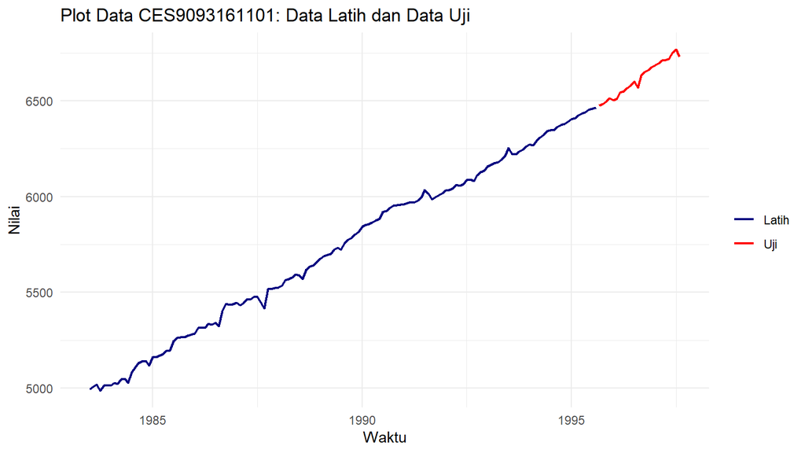

```r
df.plot <- data.frame(tgl = tgl, y = y,
                      set = rep(c("Latih", "Uji"), c(n_train, n_test)))
ggplot(df.plot, aes(tgl, y, color = set)) + geom_line(linewidth = 0.8) +
  scale_color_manual(values = c("navyblue", "red")) +
  labs(title = "Plot Data CES9093161101: Data Latih dan Data Uji",
       x = "Waktu", y = "Nilai", color = "") + theme_minimal()
```

Berdasarkan plot, data memiliki pola **trend naik** dari awal hingga akhir periode, sehingga data diduga tidak stasioner dalam rataan.

# 4 Tahap 2: Uji Stasioneritas Data Latih

## 4.1 Stasioneritas dalam Rataan

### 4.1.1 Plot Data Latih dan ACF

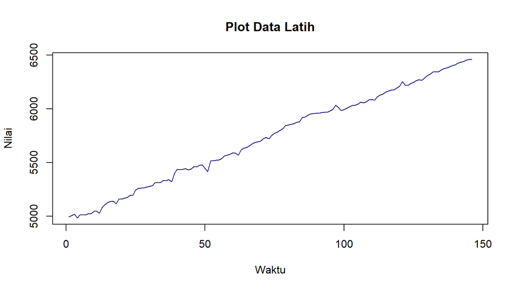

```r
plot.ts(train.ts, xlab = "Waktu", ylab = "Nilai", main = "Plot Data Latih", col = "navyblue")
```

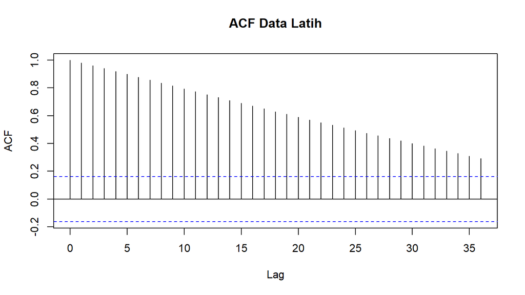

```r
acf(train.ts, lag.max = 36, main = "ACF Data Latih")
```

Plot ACF menurun secara perlahan (*tails off slowly*) yang mengindikasikan data tidak stasioner dalam rataan.

### 4.1.2 Uji ADF

$H_0$ : data tidak stasioner dalam rataan; $H_1$ : data stasioner dalam rataan

```r
adf.train <- tseries::adf.test(train.ts)
adf.train
```

```
##
##  Augmented Dickey-Fuller Test
##
## data:  train.ts
## Dickey-Fuller = -2.0163, Lag order = 5, p-value = 0.5696
## alternative hypothesis: stationary
```

Diperoleh p-value sebesar **0.5696** > 0,05 sehingga tak tolak $H_0$: data tidak stasioner dalam rataan dan perlu dilakukan differencing.

## 4.2 Stasioneritas dalam Ragam (Box-Cox)

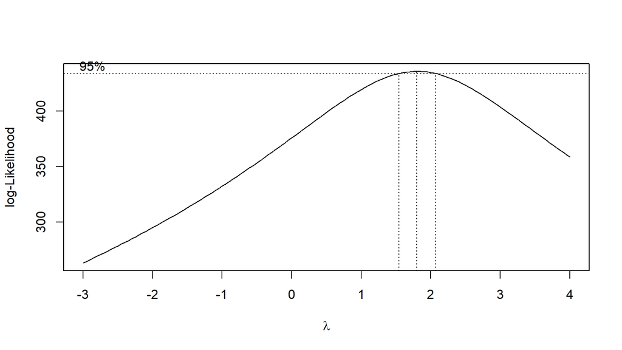

```r
index <- seq_along(train.ts)
bc <- boxcox(train.ts ~ index, lambda = seq(-3, 4, by = 0.05))
```

```r
lambda_opt <- bc$x[which.max(bc$y)]
ci_lambda  <- bc$x[bc$y > max(bc$y) - 0.5 * qchisq(0.95, df = 1)]
ci_lower <- min(ci_lambda); ci_upper <- max(ci_lambda)
c(Lambda_Optimum = lambda_opt, Batas_Bawah = ci_lower, Batas_Atas = ci_upper)
```

```
## Lambda_Optimum    Batas_Bawah     Batas_Atas
##           1.80           1.55           2.05
```

```r
ragam_stasioner <- (ci_lower <= 1 & ci_upper >= 1)
```

Nilai $\lambda$ optimum sebesar **1.8** dengan selang kepercayaan 95% **[1.55; 2.05]**. Selang tersebut **tidak memuat angka 1** sehingga data **tidak stasioner dalam ragam** dan perlu ditransformasi (transformasi Box-Cox dengan $\lambda$ optimum, dilakukan langsung pada fungsi Arima dengan argumen lambda di bawah).

```r
# lam = NULL berarti tanpa transformasi; selain itu data ditransformasi Box-Cox
lam <- if (ragam_stasioner) NULL else lambda_opt
lam
```

```
## [1] 1.8
```

# 5 Tahap 3: Penanganan Ketidakstasioneran (Differencing)

Differencing dilakukan berulang sampai uji ADF menyatakan data stasioner dalam rataan (maksimal 2 kali).

```r
base.ts <- if (is.null(lam)) train.ts else BoxCox(train.ts, lam)
d_use <- 0; z <- base.ts
while (tseries::adf.test(z)$p.value >= 0.05 && d_use < 2) {
  d_use <- d_use + 1
  z <- diff(base.ts, differences = d_use)
}
train.diff <- z
cat("Banyaknya differencing (d) =", d_use, "\n")
```

```
## Banyaknya differencing (d) = 1
```

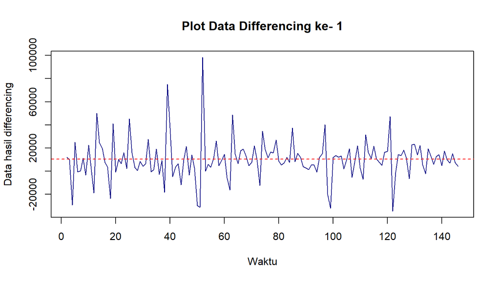

```r
plot.ts(train.diff, xlab = "Waktu", ylab = "Data hasil differencing",
        main = paste("Plot Data Differencing ke-", d_use), col = "navyblue")
abline(h = mean(train.diff), col = "red", lty = 2)
```

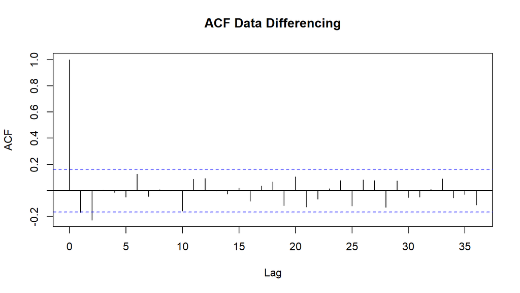

```r
acf(train.diff, lag.max = 36, main = "ACF Data Differencing")
```

```r
adf.diff <- tseries::adf.test(train.diff)
adf.diff
```

```
##
##  Augmented Dickey-Fuller Test
##
## data:  train.diff
## Dickey-Fuller = -5.8716, Lag order = 5, p-value = 0.01
## alternative hypothesis: stationary
```

Setelah differencing sebanyak **d = 1**, uji ADF memberikan p-value **0.01** < 0,05 sehingga tolak $H_0$: data sudah stasioner dalam rataan dan dapat dilanjutkan ke pemodelan.

# 6 Tahap 4: Identifikasi Model Tentatif

## 6.1 Plot ACF dan PACF

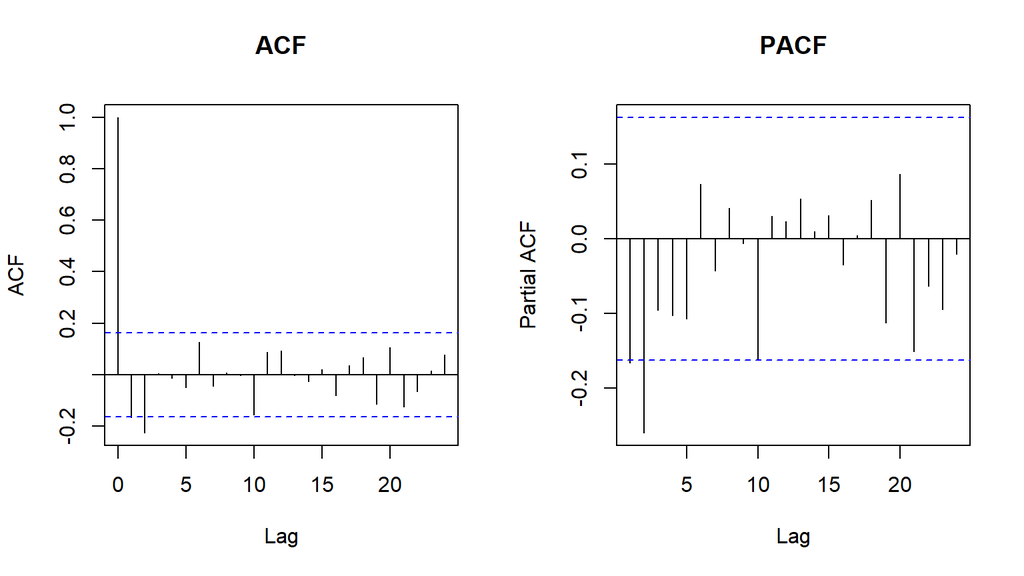

```r
par(mfrow = c(1, 2))
acf(train.diff,  lag.max = 24, main = "ACF")
pacf(train.diff, lag.max = 24, main = "PACF")
```

```r
par(mfrow = c(1, 1))
```

## 6.2 EACF

```r
TSA::eacf(train.diff, ar.max = 7, ma.max = 7)
```

```
## AR/MA
##   0 1 2 3 4 5 6 7
## 0 o x o o o o o o
## 1 x x o o o o o o
## 2 x x o o o o o o
## 3 x o o o o o o o
## 4 x o x x x o o o
## 5 x o o o x o o o
## 6 x o o o x o o o
## 7 x o o o x x o o
```

## 6.3 Daftar Model Tentatif

Kandidat di bawah ini diisi (p, q) dari hasil ACF, PACF, dan EACF di atas. **Sesuaikan** daftar ini dengan hasil identifikasi kamu.

```r
kandidat <- list(c(0,1), c(1,0), c(1,1), c(0,2), c(2,0), c(2,1), c(1,2))
nama_model <- function(p, q) paste0("ARIMA(", p, ",", d_use, ",", q, ")")
sapply(kandidat, function(k) nama_model(k[1], k[2]))
```

```
## [1] "ARIMA(0,1,1)" "ARIMA(1,1,0)" "ARIMA(1,1,1)" "ARIMA(0,1,2)" "ARIMA(2,1,0)"
## [6] "ARIMA(2,1,1)" "ARIMA(1,1,2)"
```

# 7 Tahap 5: Pendugaan Parameter, Signifikansi, dan AIC

Pendugaan parameter dengan metode *maximum likelihood*. Untuk $d = 1$ ditambahkan suku *drift* (rataan data hasil differencing). Uji signifikansi parameter menggunakan uji-z (`coeftest`) dengan $H_0$: parameter sama dengan 0.

```r
fit_arima <- function(p, q, series = train.ts) {
  Arima(series, order = c(p, d_use, q), include.drift = (d_use == 1),
        lambda = lam, method = "ML")
}
models <- lapply(kandidat, function(k) fit_arima(k[1], k[2]))

for (i in seq_along(kandidat)) {
  cat("\n=====", nama_model(kandidat[[i]][1], kandidat[[i]][2]), "=====\n")
  print(lmtest::coeftest(models[[i]]))
}
```

```
##
## ===== ARIMA(0,1,1) =====
##
## z test of coefficients:
##
##          Estimate  Std. Error z value  Pr(>|z|)
## ma1      -0.33596     0.10928 -3.0744  0.002109 **
## drift 10298.21065   933.83048 11.0279 < 2.2e-16 ***
## ---
## Signif. codes:  0 '***' 0.001 '**' 0.01 '*' 0.05 '.' 0.1 ' ' 1
##
##
## ===== ARIMA(1,1,0) =====
##
## z test of coefficients:
##
##          Estimate  Std. Error z value Pr(>|z|)
## ar1   -1.6504e-01  8.1648e-02 -2.0214  0.04324 *
## drift  1.0280e+04  1.2220e+03  8.4123  < 2e-16 ***
## ---
## Signif. codes:  0 '***' 0.001 '**' 0.01 '*' 0.05 '.' 0.1 ' ' 1
##
##
## ===== ARIMA(1,1,1) =====
##
## z test of coefficients:
##
##          Estimate  Std. Error z value  Pr(>|z|)
## ar1       0.45858     0.16189  2.8326  0.004617 **
## ma1      -0.75226     0.12269 -6.1313 8.716e-10 ***
## drift 10365.92911   637.89674 16.2502 < 2.2e-16 ***
## ---
## Signif. codes:  0 '***' 0.001 '**' 0.01 '*' 0.05 '.' 0.1 ' ' 1
##
##
## ===== ARIMA(0,1,2) =====
##
## z test of coefficients:
##
##          Estimate  Std. Error z value  Pr(>|z|)
```

[output cut: 28 more lines]

```
## ---
## Signif. codes:  0 '***' 0.001 '**' 0.01 '*' 0.05 '.' 0.1 ' ' 1
##
##
## ===== ARIMA(1,1,2) =====
##
## z test of coefficients:
##
##          Estimate  Std. Error z value Pr(>|z|)
## ar1    4.6049e-02  3.0157e-01  0.1527  0.87864
## ma1   -2.9949e-01  2.9200e-01 -1.0256  0.30506
## ma2   -2.3898e-01  1.2221e-01 -1.9555  0.05052 .
## drift  1.0359e+04  6.6519e+02 15.5729  < 2e-16 ***
## ---
## Signif. codes:  0 '***' 0.001 '**' 0.01 '*' 0.05 '.' 0.1 ' ' 1
```

```r
cek_sig <- function(m) {
  ct <- tryCatch(lmtest::coeftest(m), error = function(e) NULL)
  if (is.null(ct)) return(c(NA, NA))
  pv <- ct[!rownames(ct) %in% c("drift", "intercept"), 4]   # parameter AR/MA saja
  c(sum(pv < 0.05, na.rm = TRUE), length(pv))
}
tab <- do.call(rbind, lapply(seq_along(models), function(i) {
  s <- cek_sig(models[[i]])
  data.frame(Model = nama_model(kandidat[[i]][1], kandidat[[i]][2]),
             AIC = AIC(models[[i]]), BIC = BIC(models[[i]]),
             Signifikan = paste0(s[1], " dari ", s[2]),
             Semua_signifikan = isTRUE(s[1] == s[2]))
}))
tab <- tab[order(tab$AIC), ]; rownames(tab) <- NULL
tab
```

| Model | AIC | BIC | Signifikan | Semua_signifikan |
| --- | --- | --- | --- | --- |
| ARIMA(0,1,2) | 3233.108 | 3245.015 | 2 dari 2 | TRUE |
| ARIMA(1,1,2) | 3235.084 | 3249.968 | 0 dari 3 | FALSE |
| ARIMA(2,1,1) | 3235.280 | 3250.164 | 1 dari 3 | FALSE |
| ARIMA(1,1,1) | 3235.294 | 3247.201 | 2 dari 2 | TRUE |
| ARIMA(2,1,0) | 3236.521 | 3248.428 | 2 dari 2 | TRUE |
| ARIMA(0,1,1) | 3240.321 | 3249.251 | 1 dari 1 | TRUE |
| ARIMA(1,1,0) | 3244.560 | 3253.490 | 1 dari 1 | TRUE |

```r
pool <- if (any(tab$Semua_signifikan)) tab[tab$Semua_signifikan, ] else tab
model_terbaik_nama <- pool$Model[which.min(pool$AIC)]
idx_best <- which(sapply(kandidat, function(k) nama_model(k[1], k[2])) == model_terbaik_nama)
best <- models[[idx_best]]
pq_best <- kandidat[[idx_best]]
```

Dari model yang seluruh parameter AR/MA-nya signifikan, nilai AIC terkecil dimiliki oleh **ARIMA(0,1,2)** (AIC = 3233.11), sehingga model ini dipilih untuk dianalisis sisaannya.

```r
summary(best)
```

```
## Series: series
## ARIMA(0,1,2) with drift
## Box Cox transformation: lambda= 1.8
##
## Coefficients:
##           ma1      ma2       drift
##       -0.2572  -0.2524  10354.9382
## s.e.   0.0798   0.0785    673.2453
##
## sigma^2 = 272605853:  log likelihood = -1612.55
## AIC=3233.11   AICc=3233.39   BIC=3245.01
##
## Training set error measures:
##                      ME     RMSE     MAE          MPE      MAPE      MASE
## Training set -0.1537327 16.49262 11.3824 -0.004898987 0.2037861 0.7782563
##                    ACF1
## Training set -0.0048235
```

# 8 Tahap 6: Analisis Sisaan

## 8.1 Eksplorasi Sisaan

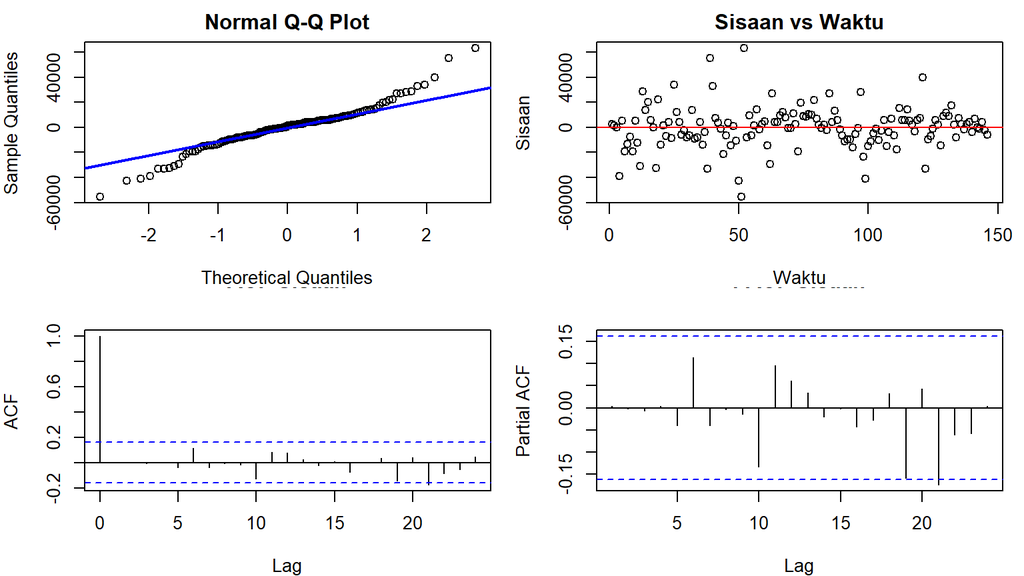

```r
sisaan <- as.numeric(residuals(best))
par(mfrow = c(2, 2), mar = c(4, 4, 2, 1))
qqnorm(sisaan, main = "Normal Q-Q Plot"); qqline(sisaan, col = "blue", lwd = 2)
plot(sisaan, type = "p", main = "Sisaan vs Waktu", xlab = "Waktu", ylab = "Sisaan"); abline(h = 0, col = "red")
acf(sisaan,  lag.max = 24, main = "ACF Sisaan")
pacf(sisaan, lag.max = 24, main = "PACF Sisaan")
```

```r
par(mfrow = c(1, 1))
```

## 8.2 Uji Formal

```r
fitdf <- pq_best[1] + pq_best[2]
uji <- list(
  ks   = ks.test(sisaan, "pnorm", mean(sisaan), sd(sisaan)),
  shap = shapiro.test(sisaan),
  lb   = Box.test(sisaan, lag = 10, type = "Ljung-Box", fitdf = fitdf),
  lb2  = Box.test(sisaan^2, lag = 10, type = "Ljung-Box"),
  t    = t.test(sisaan, mu = 0, conf.level = 0.95)
)
hasil.uji <- data.frame(
  Asumsi = c("Normalitas (Kolmogorov-Smirnov)", "Normalitas (Shapiro-Wilk)",
             "Kebebasan sisaan (Ljung-Box)", "Kehomogenan ragam (Ljung-Box sisaan kuadrat)",
             "Nilai tengah sisaan = 0 (uji-t)"),
  H0 = c("Sisaan menyebar normal", "Sisaan menyebar normal", "Sisaan saling bebas",
         "Ragam sisaan homogen", "Nilai tengah sisaan = 0"),
  p_value = c(uji$ks$p.value, uji$shap$p.value, uji$lb$p.value, uji$lb2$p.value, uji$t$p.value)
)
hasil.uji$Keputusan <- ifelse(hasil.uji$p_value < 0.05, "Tolak H0", "Gagal tolak H0")
hasil.uji$p_value <- signif(hasil.uji$p_value, 4)
hasil.uji
```

| Asumsi | H0 | p_value | Keputusan |
| --- | --- | --- | --- |
| Normalitas (Kolmogorov-Smirnov) | Sisaan menyebar normal | 8.405e-02 | Gagal tolak H0 |
| Normalitas (Shapiro-Wilk) | Sisaan menyebar normal | 1.967e-05 | Tolak H0 |
| Kebebasan sisaan (Ljung-Box) | Sisaan saling bebas | 7.430e-01 | Gagal tolak H0 |
| Kehomogenan ragam (Ljung-Box sisaan kuadrat) | Ragam sisaan homogen | 2.115e-05 | Tolak H0 |
| Nilai tengah sisaan = 0 (uji-t) | Nilai tengah sisaan = 0 | 9.526e-01 | Gagal tolak H0 |

# 9 Tahap 7: Overfitting

Overfitting dilakukan dengan menaikkan orde AR dan MA masing-masing satu tingkat dari model terbaik, yaitu **ARIMA(1,1,2)** dan **ARIMA(0,1,3)**. Model hasil overfitting dianggap lebih baik hanya jika AIC lebih kecil **dan** parameter tambahannya signifikan.

```r
over_list <- list(c(pq_best[1] + 1, pq_best[2]), c(pq_best[1], pq_best[2] + 1))
over_models <- lapply(over_list, function(k) fit_arima(k[1], k[2]))

for (i in seq_along(over_list)) {
  cat("\n=====", nama_model(over_list[[i]][1], over_list[[i]][2]), "=====\n")
  print(lmtest::coeftest(over_models[[i]]))
}
```

```
##
## ===== ARIMA(1,1,2) =====
##
## z test of coefficients:
##
##          Estimate  Std. Error z value Pr(>|z|)
## ar1    4.6049e-02  3.0157e-01  0.1527  0.87864
## ma1   -2.9949e-01  2.9200e-01 -1.0256  0.30506
## ma2   -2.3898e-01  1.2221e-01 -1.9555  0.05052 .
## drift  1.0359e+04  6.6519e+02 15.5729  < 2e-16 ***
## ---
## Signif. codes:  0 '***' 0.001 '**' 0.01 '*' 0.05 '.' 0.1 ' ' 1
##
##
## ===== ARIMA(0,1,3) =====
##
## z test of coefficients:
##
##          Estimate  Std. Error z value  Pr(>|z|)
## ma1   -2.5346e-01  8.3461e-02 -3.0369  0.002390 **
## ma2   -2.5044e-01  7.9908e-02 -3.1341  0.001724 **
## ma3   -1.2830e-02  7.9443e-02 -0.1615  0.871705
## drift  1.0359e+04  6.6441e+02 15.5919 < 2.2e-16 ***
## ---
## Signif. codes:  0 '***' 0.001 '**' 0.01 '*' 0.05 '.' 0.1 ' ' 1
```

```r
# parameter tambahan = AR/MA berorde tertinggi yang baru
sig_param_baru <- function(m, nama_param) {
  ct <- lmtest::coeftest(m)
  isTRUE(ct[nama_param, 4] < 0.05)
}
over_tab <- data.frame(
  Model = c(model_terbaik_nama, sapply(over_list, function(k) nama_model(k[1], k[2]))),
  AIC = c(AIC(best), sapply(over_models, AIC)),
  BIC = c(BIC(best), sapply(over_models, BIC)),
  Parameter_tambahan_signifikan = c(NA,
        sig_param_baru(over_models[[1]], paste0("ar", over_list[[1]][1])),
        sig_param_baru(over_models[[2]], paste0("ma", over_list[[2]][2])))
)
over_tab
```

| Model | AIC | BIC | Parameter_tambahan_signifikan |
| --- | --- | --- | --- |
| ARIMA(0,1,2) | 3233.108 | 3245.015 | NA |
| ARIMA(1,1,2) | 3235.084 | 3249.968 | FALSE |
| ARIMA(0,1,3) | 3235.082 | 3249.965 | FALSE |

```r
lebih_baik <- which(over_tab$AIC[-1] < over_tab$AIC[1] & over_tab$Parameter_tambahan_signifikan[-1] %in% TRUE)
if (length(lebih_baik) > 0) {
  pilih <- lebih_baik[which.min(over_tab$AIC[-1][lebih_baik])]
  final_model <- over_models[[pilih]]; final_nama <- over_tab$Model[pilih + 1]
} else {
  final_model <- best; final_nama <- model_terbaik_nama
}
final_pq <- as.numeric(arimaorder(final_model))[c(1, 3)]
```

Hasil overfitting: model terbaik akhir adalah **ARIMA(0,1,2)** (model hasil overfitting tidak lebih baik: AIC tidak lebih kecil atau parameter tambahan tidak signifikan).

# 10 Tahap 8: Peramalan

## 10.1 Model Akhir

```r
summary(final_model)
```

```
## Series: series
## ARIMA(0,1,2) with drift
## Box Cox transformation: lambda= 1.8
##
## Coefficients:
##           ma1      ma2       drift
##       -0.2572  -0.2524  10354.9382
## s.e.   0.0798   0.0785    673.2453
##
## sigma^2 = 272605853:  log likelihood = -1612.55
## AIC=3233.11   AICc=3233.39   BIC=3245.01
##
## Training set error measures:
##                      ME     RMSE     MAE          MPE      MAPE      MASE
## Training set -0.1537327 16.49262 11.3824 -0.004898987 0.2037861 0.7782563
##                    ACF1
## Training set -0.0048235
```

## 10.2 Peramalan pada Data Uji

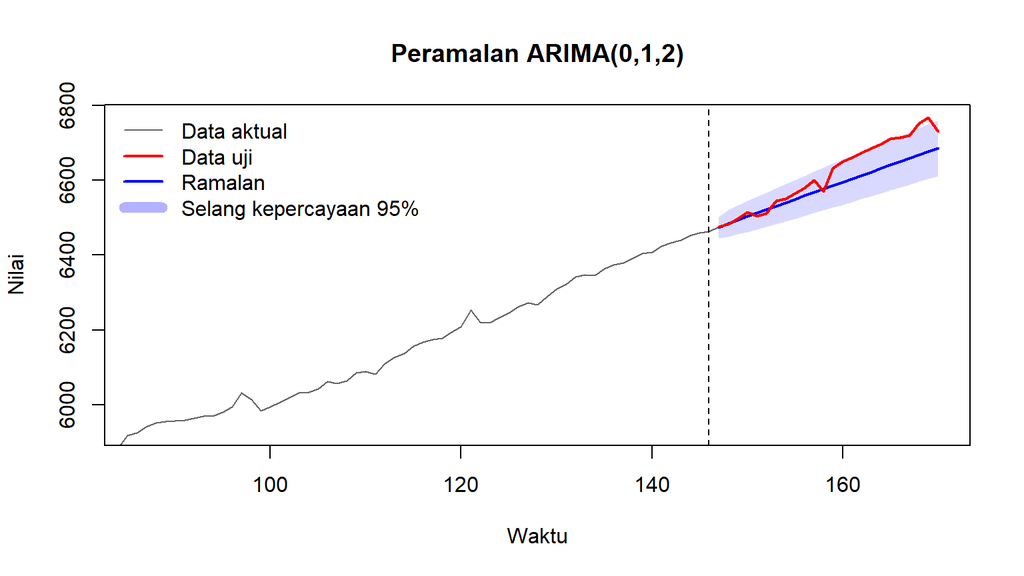

```r
fc <- forecast(final_model, h = n_test, level = 95)

plot(seq_len(n), y, type = "l", col = "grey40", xlab = "Waktu", ylab = "Nilai",
     main = paste("Peramalan", final_nama), xlim = c(n_train - 60, n),
     ylim = range(c(y[(n_train - 60):n], fc$lower, fc$upper)))
polygon(c(n_train + seq_len(n_test), rev(n_train + seq_len(n_test))),
        c(fc$lower, rev(fc$upper)), col = rgb(0, 0, 1, 0.15), border = NA)
lines(n_train + seq_len(n_test), as.numeric(fc$mean), col = "blue", lwd = 2)
lines(n_train + seq_len(n_test), test, col = "red", lwd = 2)
abline(v = n_train, lty = 2)
legend("topleft", c("Data aktual", "Data uji", "Ramalan", "Selang kepercayaan 95%"),
       col = c("grey40", "red", "blue", rgb(0, 0, 1, 0.3)), lwd = c(1, 2, 2, 8), bty = "n")
```

## 10.3 Akurasi Peramalan

```r
acc <- accuracy(fc, test)
acc
```

```
##                      ME     RMSE      MAE          MPE      MAPE      MASE
## Training set -0.1537327 16.49262 11.38240 -0.004898987 0.2037861 0.7782563
## Test set     35.1365232 47.04753 37.59377  0.524950689 0.5626384 2.5704231
##                    ACF1
## Training set -0.0048235
## Test set             NA
```

```r
hasil.ramal <- data.frame(Tanggal = tgl.test, Aktual = test,
                          Ramalan = round(as.numeric(fc$mean), 1),
                          Bawah95 = round(as.numeric(fc$lower), 1),
                          Atas95 = round(as.numeric(fc$upper), 1))
hasil.ramal
```

| Tanggal | Aktual | Ramalan | Bawah95 | Atas95 |
| --- | --- | --- | --- | --- |
| 1995-09-01 | 6476.0 | 6474.2 | 6445.3 | 6503.1 |
| 1995-10-01 | 6482.3 | 6484.8 | 6448.7 | 6520.7 |
| 1995-11-01 | 6496.7 | 6494.0 | 6455.3 | 6532.5 |
| 1995-12-01 | 6514.4 | 6503.2 | 6462.0 | 6544.2 |
| 1996-01-01 | 6503.4 | 6512.4 | 6468.9 | 6555.7 |
| 1996-02-01 | 6510.7 | 6521.6 | 6475.9 | 6567.1 |
| 1996-03-01 | 6544.5 | 6530.8 | 6483.0 | 6578.3 |
| 1996-04-01 | 6550.1 | 6540.0 | 6490.2 | 6589.5 |
| 1996-05-01 | 6564.4 | 6549.2 | 6497.5 | 6600.5 |
| 1996-06-01 | 6579.2 | 6558.3 | 6504.8 | 6611.5 |

[output cut: 14 more lines]

Pada data uji, model **ARIMA(0,1,2)** menghasilkan MAPE sebesar **0.56%** dan RMSE **47.05**. Nilai MAPE di bawah 10% sehingga kemampuan peramalan tergolong sangat baik.

## 10.4 Peramalan ke Depan (12 Bulan)

Model dengan orde yang sama diduga ulang menggunakan seluruh data, kemudian digunakan untuk meramal 12 bulan setelah amatan terakhir.

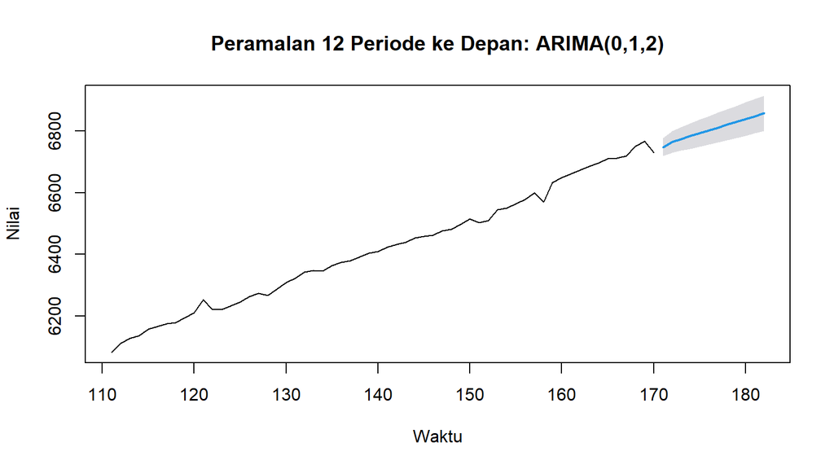

```r
full.ts <- ts(y)
fit.full <- Arima(full.ts, order = c(final_pq[1], d_use, final_pq[2]),
                  include.drift = (d_use == 1), lambda = lam, method = "ML")
fc.future <- forecast(fit.full, h = 12, level = 95)
plot(fc.future, include = 60, main = paste("Peramalan 12 Periode ke Depan:", final_nama),
     xlab = "Waktu", ylab = "Nilai")
```

```r
data.frame(Periode = seq_len(12), Ramalan = round(as.numeric(fc.future$mean), 1),
           Bawah95 = round(as.numeric(fc.future$lower), 1), Atas95 = round(as.numeric(fc.future$upper), 1))
```

| Periode | Ramalan | Bawah95 | Atas95 |
| --- | --- | --- | --- |
| 1 | 6748.1 | 6719.1 | 6777.0 |
| 2 | 6765.6 | 6729.9 | 6801.2 |
| 3 | 6774.9 | 6736.4 | 6813.3 |
| 4 | 6784.2 | 6743.0 | 6825.2 |
| 5 | 6793.5 | 6749.8 | 6836.9 |
| 6 | 6802.7 | 6756.8 | 6848.4 |
| 7 | 6812.0 | 6763.8 | 6859.8 |
| 8 | 6821.2 | 6771.0 | 6871.1 |
| 9 | 6830.4 | 6778.2 | 6882.4 |
| 10 | 6839.6 | 6785.5 | 6893.5 |

[output cut: 2 more lines]

# 11 Kesimpulan

Data CES9093161101 dengan 170 amatan dibagi menjadi 146 data latih dan 24 data uji. Data latih tidak stasioner dalam rataan sehingga dilakukan differencing sebanyak 1 kali dan tidak stasioner dalam ragam sehingga ditransformasi Box-Cox. Model terbaik berdasarkan AIC, signifikansi parameter, dan overfitting adalah **ARIMA(0,1,2)** dengan MAPE data uji sebesar 0.56%.